# Modelo Obtención Log Odd-Ratio en Sujetos Control

```r
library(dplyr)
library(ggplot2)
library(gridExtra)
library(MASS)
library(fitdistrplus)
library(ggstatsplot)
library(tibble)
library(readr)
```

# Modelo Causal Tractos Esquizofrenia

Funciones

```r
logistic.regression.or.ci <- function(regress.out, level = 0.95) {
  usual.output <- summary(regress.out)
  z.quantile <- stats::qnorm(1 - (1 - level) / 2)
  number.vars <- length(regress.out$coefficients)
  OR <- exp(regress.out$coefficients[-1])
  temp.store.result <- matrix(rep(NA, number.vars * 2), nrow = number.vars)
  for (i in 1:number.vars) {
    temp.store.result[i, ] <- summary(regress.out)$coefficients[i] +
      c(-1, 1) * z.quantile * summary(regress.out)$coefficients[i + number.vars]
  }
  intercept.ci <- temp.store.result[1, ]
  slopes.ci <- temp.store.result[-1, ]
  OR.ci <- exp(slopes.ci)
  output <- list(
    regression.table = usual.output, intercept.ci = intercept.ci,
    slopes.ci = slopes.ci, OR = OR, OR.ci = OR.ci
  )
  return(output)
}
```

## Etapa 1 - definición de los datos expuestos y no expuestos

Obtener datos de sujetos de control y estudio. Ajustar para su análisis posterior

```r
# confusoras DAG= "sl2l_qa", "sl2l_iso","ecpl_qa", "ecpl_iso","age", "gender_F",
# features predictoras = "sl2l_diameter","ccbd_diameter","ifol_diameter","ecpl_volume","tral_volume","sl2l_mean_length","ccbd_mean_length"

setwd("C:/hcgalvan/Repositorios/hcgalvan_project/data/union/End")
temp = gsub(".*target.*", "", readLines("integrado.csv"))
data<-read.table(text=temp, sep=",", header=TRUE)

t<-data.frame(data[,c("sl2l_diameter","ccbd_diameter","ifol_diameter","ecpl_volume","tral_volume","sl2l_mean_length","ccbd_mean_length","label","sl2l_qa", "sl2l_iso", "ccbd_iso", "ccbd_qa", "ifol_qa", "ifol_iso", "ecpl_qa", "ecpl_iso", "tral_qa", "tral_iso", "afsl_qa", "afsl_iso", "afsr_qa", "afsr_iso", "cfpl_iso", "cfpl_qa", "cfpr_iso", "cfpr_qa", "fatl_iso", "fatl_qa", "fatr_iso", "fatr_qa", "slfl_iso", "slfl_qa", "slfr_iso", "slfr_qa", "tral_iso", "tral_qa", "ufsl_iso", "ufsl_qa", "ufsr_iso", "ufsr_qa", "age", "gender_F")])

t$gend_F <- ifelse(t$gender_F == "True", 1, 0) #convierto en = o 1
t <- subset(t, select = -c(gender_F)) # Quito de tabla
```

### Creación de features expuestos y no expuestos

Definición de nuevas variables como Expuesto y no Expuesto obtenido del analisis de su real distribución empírica. Donde False = No Expuesto = 0; True = Expuesto = 1

```r
 #  Min. 1st Qu.  Median    Mean 3rd Qu.    Max.
 # 19.86   22.10   23.02   23.30   24.42   27.18
t<- t %>%
  mutate(sl2ldmExp = if_else((t$sl2l_diameter > 22.10 & t$sl2l_diameter < 24.42), 0, 1))
#21.73   26.07   28.18   28.29   30.23   32.90
t<- t %>%
  mutate(ccbdmExp = if_else((t$ccbd_diameter > 26.07 & t$ccbd_diameter < 30.23), 0, 1))
#11.70   14.68   15.91   15.73   16.51   19.64
t<- t %>%
  mutate(ifoldmExp = if_else((t$ifol_diameter > 14.68 & t$ifol_diameter < 16.51), 0, 1))
 #1785    6455    7407    7250    8918   10622
t<- t %>%
  mutate(ecplvlExp = if_else((t$ecpl_volume > 6455 & t$ecpl_volume < 8918), 0, 1))
#7780   12366   15988   15911   18004   26424
t<- t %>%
  mutate(tralvlExp = if_else((t$tral_volume > 12366 & t$tral_volume < 18004), 0, 1))
#65.44   72.18   75.69   76.94   80.61   88.53
t<- t %>%
  mutate(sl2lmlExp = if_else((t$sl2l_mean_length > 72.18 & t$sl2l_mean_length < 80.61), 0, 1))
  #99.87  112.62  117.22  117.47  123.81  131.73
t<- t %>%
  mutate(ccbdmlExp = if_else((t$ccbd_mean_length > 112.62 & t$ccbd_mean_length < 123.81), 0, 1))
```

```r
#par(mfrow = c(2, 2), mar = c(2, 2, 2, 2))
xtabs(~sl2ldmExp,t);xtabs(~ccbdmExp,t);xtabs(~ifoldmExp,t);xtabs(~ecplvlExp,t);xtabs(~tralvlExp,t);xtabs(~sl2lmlExp,t)
```

```
sl2ldmExp
 0  1
38 58
ccbdmExp
 0  1
47 49
ifoldmExp
 0  1
39 57
ecplvlExp
 0  1
42 54
tralvlExp
 0  1
43 53
sl2lmlExp
 0  1
47 49
```

```r
xtabs(~ccbdmlExp,t)
```

```
ccbdmlExp
 0  1
37 59
```

```r
tx<-c()
########################
tx$Esquiz <- ifelse(t$label == 0, "SI", "NO")
tx$sl2sdmd <- ifelse(t$sl2ldmExp == 0, "NO", "SI")
xtabs(~sl2sdmd+Esquiz,tx) #table of counts per stratum
```

```
       Esquiz
sl2sdmd NO SI
     NO 23 15
     SI 27 31
```

```r
odd <- ((31/27)/(15/23))
p <- (46/(23+15+27+31))
sprintf("odd: %f", odd)
```

```
[1] "odd: 1.760494"
```

```r
sprintf("log odd: %f", log(odd))
```

```
[1] "log odd: 0.565594"
```

```r
sprintf("Prob(Ezq): %f", p)
```

```
[1] "Prob(Ezq): 0.479167"
```

```r
v1 <- p*(27+31)
v2 <- (27+31)-v1
v3 <- p*(23+15)
v4 <- (23+15)-v3
pval <- 1-((v1/v2)/(v3/v3))
pval
```

```
[1] 0.08
```

```r
((11.2/128.8)/(198.7/17.3))
```

```
[1] 0.00757095
```

```r
########################
tx$ccbdmd <- ifelse(t$ccbdmExp == 0, "NO", "SI")
xtabs(~ccbdmd+Esquiz,tx) #table of counts per stratum
```

```
      Esquiz
ccbdmd NO SI
    NO 25 22
    SI 25 24
```

```r
odd1 <- ((24/25)/(22/25)) ### ERROR
p1 <- (46/(50+46))
sprintf("odd: %f", odd1)
```

```
[1] "odd: 1.090909"
```

```r
sprintf("log odd: %f", log(odd1))
```

```
[1] "log odd: 0.087011"
```

```r
sprintf("Prob(Ezq): %f", p1)
```

```
[1] "Prob(Ezq): 0.479167"
```

```r
########################
tx$ifoldmd <- ifelse(t$ifoldmExp == 0, "NO", "SI")
xtabs(~ifoldmd+Esquiz,tx) #table of counts per stratum
```

```
       Esquiz
ifoldmd NO SI
     NO 23 16
     SI 27 30
```

```r
odd2 <- ((27/30)/(16/23)) ### ERROR
p2 <- ((27+16)/(30+23+27+16))
sprintf("odd: %f", odd2)
```

```
[1] "odd: 1.293750"
```

```r
sprintf("log odd: %f", log(odd2))
```

```
[1] "log odd: 0.257545"
```

```r
sprintf("Prob(Ezq): %f", p2)
```

```
[1] "Prob(Ezq): 0.447917"
```

```r
########################
tx$sl2lmld <- ifelse(t$sl2lmlExp == 0, "NO", "SI")
xtabs(~sl2lmld+Esquiz,tx) #table of counts per stratum
```

```
       Esquiz
sl2lmld NO SI
     NO 25 22
     SI 25 24
```

```r
odd3 <- ((24/25)/(22/25)) ### ERROR
p3 <- ((24+22)/(25+25+24+22))
sprintf("odd: %f", odd3)
```

```
[1] "odd: 1.090909"
```

```r
sprintf("log odd: %f", log(odd3))
```

```
[1] "log odd: 0.087011"
```

```r
sprintf("Prob(Ezq): %f", p3)
```

```
[1] "Prob(Ezq): 0.479167"
```

```r
########################
tx$ecplvld <- ifelse(t$ecplvlExp == 0, "NO", "SI")
xtabs(~ecplvld+Esquiz,tx) #table of counts per stratum
```

```
       Esquiz
ecplvld NO SI
     NO 26 16
     SI 24 30
```

```r
odd4 <- ((30/24)/(16/26)) ### ERROR
p4 <- ((30+16)/(24+26+30+16))
sprintf("odd: %f", odd4)
```

```
[1] "odd: 2.031250"
```

```r
sprintf("log odd: %f", log(odd4))
```

```
[1] "log odd: 0.708651"
```

```r
sprintf("Prob(Ezq): %f", p4)
```

```
[1] "Prob(Ezq): 0.479167"
```

```r
########################
tx$tralvld <- ifelse(t$tralvlExp == 0, "NO", "SI")
xtabs(~tralvld+Esquiz,tx) #table of counts per stratum
```

```
       Esquiz
tralvld NO SI
     NO 24 19
     SI 26 27
```

```r
odd5 <- ((27/26)/(19/24)) ### ERROR
p5 <- ((27+19)/(26+24+27+19))
sprintf("odd: %f", odd5)
```

```
[1] "odd: 1.311741"
```

```r
sprintf("log odd: %f", log(odd5))
```

```
[1] "log odd: 0.271355"
```

```r
sprintf("Prob(Ezq): %f", p5)
```

```
[1] "Prob(Ezq): 0.479167"
```

```r
########################
tx$ccbdmld <- ifelse(t$ccbdmlExp == 0, "NO", "SI")
xtabs(~ccbdmld+Esquiz,tx) #table of counts per stratum
```

```
       Esquiz
ccbdmld NO SI
     NO 24 13
     SI 26 33
```

```r
odd6 <- ((33/26)/(13/24)) ### ERROR
p6 <- ((33+13)/(26+24+33+13))
sprintf("odd: %f", odd6)
```

```
[1] "odd: 2.343195"
```

```r
sprintf("log odd: %f", log(odd6))
```

```
[1] "log odd: 0.851515"
```

```r
sprintf("Prob(Ezq): %f", p6)
```

```
[1] "Prob(Ezq): 0.479167"
```

### Creación de variable A a partir de los expuestos y no expuestos

```r
#t <- subset(t, select = -c(A)) # Quito de tabla
suma = 0
resultado <- c()
for (i in 1:length(t$label)){
#  suma = sum(t$sl2ldmExp[i], t$sl2lmlExp[i], t$ccbdmExp[i], t$ccbdmlExp[i], t$tralvlExp[i], t$ecplvlExp[i], t$ifoldmExp[i] )
#  suma = sum(t$sl2ldmExp[i], t$ccbdmlExp[i], t$tralvlExp[i], t$ecplvlExp[i], t$ifoldmExp[i] )
  suma = sum(t$ccbdmlExp[i], t$ecplvlExp[i]) # solo los 2 mas altos odds: 2.03; 2.34
#  suma = sum(t$sl2lmlExp[i], t$ccbdmExp[i])
#  suma = sum(t$sl2ldmExp[i], t$ccbdmlExp[i], t$ecplvlExp[i]) # solo dejo estos que tienen odds altos 1.76; 2.03; 2.34

  resultado[length(resultado) + 1] <- if_else((suma >=1 ),1, 0)
}
xtabs(~resultado)
```

```
resultado
 0  1
15 81
```

```r
t$A <- resultado
xtabs(~A,t)
```

```
A
 0  1
15 81
```

```r
sujeto_Ctrl <- dplyr::select(dplyr::filter(t, label == 1), "A")
sujeto_Est <- dplyr::select(dplyr::filter(t, label == 0), "A")
xtabs(~A,sujeto_Ctrl)
```

```
A
 0  1
12 38
```

```r
xtabs(~A,sujeto_Est)
```

```
A
 0  1
 3 43
```

#### Valor obtenido a partir del feature dependiente A y Confusoras como predictoras.

##### Reducir con PCA las predictoras.

```r
### Seleccion de features filtrando sujetos de control
t3 <- dplyr::select(dplyr::filter(t, label == 1), "sl2l_qa", "sl2l_iso", "ccbd_iso", "ccbd_qa", "ifol_qa", "ifol_iso", "ecpl_qa", "ecpl_iso", "tral_qa", "tral_iso", "afsl_qa", "afsl_iso", "afsr_qa", "afsr_iso", "cfpl_iso", "cfpl_qa", "cfpr_iso", "cfpr_qa", "fatl_iso", "fatl_qa", "fatr_iso", "fatr_qa", "slfl_iso", "slfl_qa", "slfr_iso", "slfr_qa", "tral_iso", "tral_qa", "ufsl_iso", "ufsl_qa", "ufsr_iso", "ufsr_qa", "age", "gend_F", "A")
```

```r
### No incluye esta lista a feature A para poder realizar escalado de datos
lista<-c("sl2l_qa", "sl2l_iso", "ccbd_iso", "ccbd_qa", "ifol_qa", "ifol_iso", "ecpl_qa", "ecpl_iso", "tral_qa", "tral_iso", "afsl_qa", "afsl_iso", "afsr_qa", "afsr_iso", "cfpl_iso", "cfpl_qa", "cfpr_iso", "cfpr_qa", "fatl_iso", "fatl_qa", "fatr_iso", "fatr_qa", "slfl_iso", "slfl_qa", "slfr_iso", "slfr_qa", "tral_iso", "tral_qa", "ufsl_iso", "ufsl_qa", "ufsr_iso", "ufsr_qa", "age", "gend_F")
```

#### Se realiza el normalizado para dejarlo en valores tipo Z

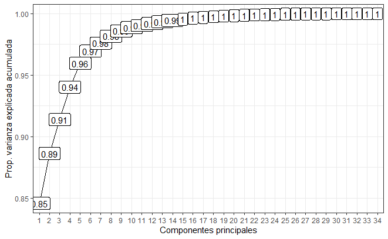

```r
pca.out3 <- prcomp(t3[,c(lista)],
                  scale. = TRUE)
#pca.out3$x
pca.var3 <- pca.out3$sdev^2  #autovalores
# Cálculo de la varianza explicada acumulada
prop_varianza <- pca.out3$sdev^2/sum(pca.out3$sdev^2)
prop_varianza_acum <- cumsum(prop_varianza)
ggplot(data = data.frame(prop_varianza_acum, pc = factor(1:34)),
       aes(x = pc, y = prop_varianza_acum, group = 1)) +
  geom_point() +
  geom_line() +
  geom_label(aes(label = round(prop_varianza_acum,2))) +
  theme_bw() +
  labs(x = "Componentes principales",
       y = "Prop. varianza explicada acumulada")
```

### Regresion logística binomial con PCA para obtener coeficientes

```r
#disable scientific notation for model summary
options(scipen=999)

#pca.var3
misdatos2 <- data.frame(A = t3[, "A"], pca.out3$x[, 1:2])

#pca.out3[1]
logRegPCANoExp <- glm(A ~ .,  data = misdatos2, family = binomial)

#summary(logRegPCA)
logistic.regression.or.ci(logRegPCANoExp)
```

```
$regression.table

Call:
glm(formula = A ~ ., family = binomial, data = misdatos2)

Coefficients:
            Estimate Std. Error z value Pr(>|z|)
(Intercept)  1.15736    0.33248   3.481   0.0005 ***
PC1         -0.01500    0.06277  -0.239   0.8111
PC2          0.09316    0.28461   0.327   0.7434
---
Signif. codes:  0 ‘***’ 0.001 ‘**’ 0.01 ‘*’ 0.05 ‘.’ 0.1 ‘ ’ 1

(Dispersion parameter for binomial family taken to be 1)

    Null deviance: 55.108  on 49  degrees of freedom
Residual deviance: 54.943  on 47  degrees of freedom
AIC: 60.943

Number of Fisher Scoring iterations: 4


$intercept.ci
[1] 0.5057146 1.8090041

$slopes.ci
           [,1]      [,2]
[1,] -0.1380227 0.1080163
[2,] -0.4646701 0.6509982

$OR
      PC1       PC2
0.9851087 1.0976418

$OR.ci
          [,1]     [,2]
[1,] 0.8710789 1.114066
[2,] 0.6283423 1.917454
```

```r
summary(logRegPCANoExp)$coefficients
```

```
               Estimate Std. Error    z value     Pr(>|z|)
(Intercept)  1.15735931 0.33247791  3.4810111 0.0004995247
PC1         -0.01500324 0.06276621 -0.2390337 0.8110794229
PC2          0.09316403 0.28461449  0.3273341 0.7434152053
```

```r
pscl::pR2(logRegPCANoExp)["McFadden"]
```

```
fitting null model for pseudo-r2
  McFadden
0.00298859
```

```r
caret::varImp(logRegPCANoExp)
```

|  | Overall |
| --- | --- |
| PC1 | 0.2390337 |
| PC2 | 0.3273341 |

```r
car::vif(logRegPCANoExp)
```

```
     PC1      PC2
1.000001 1.000001
```

```r
library(robustbase)
library(survival)
str(t3)
```

```
'data.frame':   50 obs. of  33 variables:
 $ sl2l_qa : num  0.208 0.075 0.088 0.191 0.227 ...
 $ sl2l_iso: num  0.536 0.2 0.233 0.5 0.597 ...
 $ ccbd_iso: num  0.446 0.189 0.213 0.464 0.569 ...
 $ ccbd_qa : num  0.2152 0.0897 0.1208 0.2396 0.3016 ...
 $ ifol_qa : num  0.2203 0.0876 0.1117 0.2282 0.3078 ...
 $ ifol_iso: num  0.433 0.204 0.228 0.463 0.605 ...
 $ ecpl_qa : num  0.184 0.193 0.193 0.19 0.193 ...
 $ ecpl_iso: num  0.563 0.515 0.515 0.511 0.515 ...
 $ tral_qa : num  0.1613 0.0713 0.0916 0.1561 0.2099 ...
 $ tral_iso: num  0.401 0.179 0.218 0.403 0.562 ...
 $ afsl_qa : num  0.226 0.0845 0.1048 0.2076 0.2818 ...
 $ afsl_iso: num  0.482 0.178 0.219 0.473 0.593 ...
 $ afsr_qa : num  0.1759 0.0896 0.1086 0.1949 0.296 ...
 $ afsr_iso: num  0.568 0.215 0.236 0.489 0.646 ...
```

[output cut: 19 more lines]

```r
datglmrob<-glmrob(formula = A ~ ., data= misdatos2, family = "binomial", method = "BY")
```

```
Convergence Achieved
```

```r
summary(datglmrob)
```

```
Call:  glmrob(formula = A ~ ., family = "binomial", data = misdatos2,      method = "BY")


Coefficients:
            Estimate Std. Error z value Pr(>|z|)
(Intercept)  1.15614    0.33192   3.483 0.000496 ***
PC1         -0.01542    0.07857  -0.196 0.844411
PC2          0.07934    0.22863   0.347 0.728580
---
Signif. codes:  0 ‘***’ 0.001 ‘**’ 0.01 ‘*’ 0.05 ‘.’ 0.1 ‘ ’ 1
Robustness weights w.r * w.x:
integer(0)

Number of observations: 0
Fitted by method ‘BY’  (in 5 iterations)

(Dispersion parameter for  family taken to be 1)

No deviance values available
Algorithmic parameters:
const
  0.5
maxhalf   maxit
     10    1000
```

```r
pscl::pR2(datglmrob)["McFadden"]
```

```
Error in if (fam %in% c("gaussian", "Gamma", "inverse.gaussian")) p <- p +  :
  argumento tiene longitud cero
```

```r
datglmrob$coefficients
```

```
(Intercept)         PC1         PC2
 1.15613748 -0.01542028  0.07933723
```

```r
logRegPCANoExp$coefficients
```

```
(Intercept)         PC1         PC2
 1.15735931 -0.01500324  0.09316403
```

#### Generación Propensity Z Score con PCA

Aquí es un trabajo manual para cada prueba a realizar. Cada regresión tiene que ser ajustada.

```r
############## PARA SUJETOS DE CONTROL #######################
zscores2<-c()
for(i in 1:50) {       # for-loop over rows
    zscores2[i] <-((1/(1+exp(-(as.numeric(unlist(logRegPCANoExp$coefficients[1]))+as.numeric(unlist(logRegPCANoExp$coefficients[2]))*as.numeric(unlist(pca.out3$x[i,"PC1"]))+as.numeric(unlist(logRegPCANoExp$coefficients[3]))*as.numeric(unlist(pca.out3$x[i,"PC2"])))))))
}
t3$zscore <-zscores2
quantile(t3$zscore)
```

```
       0%       25%       50%       75%      100%
0.6845395 0.7449761 0.7594602 0.7728350 0.8143427
```

### Piece-wice constant function - Approximate λ(Zi) using histogram splines

```r
# Utilizo los cuantiles de EXPUESTOS para armar stratos de zscore en LOS NO EXPUESTOS
#quintil <-quantile(t3$zscore, prob = seq(0, 1, 1/5))
#t3$subclass <- cut(x=t3$zscore,
#                              breaks=quantile(quintil,
#                              prob = seq(0, 1, 1/5)),include.lowest=T)
cuantil <-quantile(t3$zscore, prob = seq(0, 1, 1/5))
t3$subclass <- cut(x=t3$zscore,
                              breaks=quantile(cuantil,
                              prob = seq(0, 1, 1/5)),include.lowest=T)
levels(t3$subclass) <- 1:length(levels(t3$subclass))

t3$subclass
```

```
 [1] 2 4 1 4 3 3 5 3 2 2 4 2 1 5 4 2 2 1 4 2 4 3 4 2 5 4 5 3 5 5 1 4 3 1 5 3 4 1 2 2 1 1 5 1 3 1 3 5 5 3
Levels: 1 2 3 4 5
```

```r
xtabs(~A+subclass,t3)
```

```
   subclass
A   1 2 3 4 5
  0 2 4 2 3 1
  1 8 6 8 7 9
```

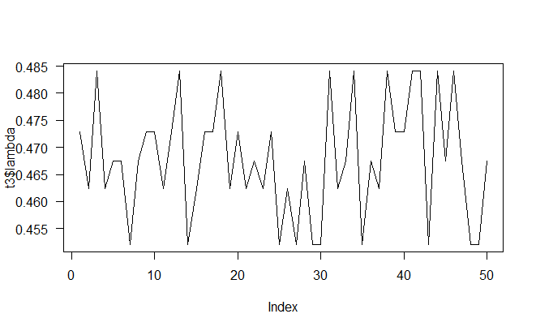

```r
# utilizar los quintiles y definir los valores medios
b1 = mean(as.numeric(unlist(dplyr::select(dplyr::filter(t3, subclass == 1,),"zscore"))))
b2 = mean(as.numeric(unlist(dplyr::select(dplyr::filter(t3, subclass == 2,),"zscore"))))
b3 = mean(as.numeric(unlist(dplyr::select(dplyr::filter(t3, subclass == 3,),"zscore"))))
b4 = mean(as.numeric(unlist(dplyr::select(dplyr::filter(t3, subclass == 4,),"zscore"))))
b5 = mean(as.numeric(unlist(dplyr::select(dplyr::filter(t3, subclass == 5,),"zscore"))))

# Determinar los valores representativos
α_1 = exp(-b1)
α_2 = exp(-b2)
α_3 = exp(-b3)
α_4 = exp(-b4)
α_5 = exp(-b5)

### Obtengo los límites de zscore a partir del filtro subclase y utilizar en la función por partes

lim1 <- max(as.numeric(unlist(dplyr::select(dplyr::filter(t3, subclass == 1,),"zscore"))))
lim2 <- max(as.numeric(unlist(dplyr::select(dplyr::filter(t3, subclass == 2,),"zscore"))))
lim3 <- max(as.numeric(unlist(dplyr::select(dplyr::filter(t3, subclass == 3,),"zscore"))))
lim4 <- max(as.numeric(unlist(dplyr::select(dplyr::filter(t3, subclass == 4,),"zscore"))))
lim5 <- max(as.numeric(unlist(dplyr::select(dplyr::filter(t3, subclass == 5,),"zscore"))))


fx <- function(x, dat){
    f <- NULL
    ifelse (x > 0 & x<= lim1, f <- α_1, 0)
    ifelse (x>lim1 & x<=lim2, f <- α_2, 0)
    ifelse (x>lim2 & x<=lim3, f <- α_3, 0)
    ifelse (x>lim3 & x<=lim4, f <- α_4, 0)
    ifelse (x>lim4, f <- α_5, 0)
    f
}

x <- data.frame(t3$zscore)
for(i in 1:nrow(x)) {       # for-loop over rows
  lambd <- fx(t3$zscore[[i]])
  t3$lambda[i] <- lambd
}

plot(t3$lambda, type="l", las=1)
points(x)
```

### Ajustar con MLE (Maximum Likelihood Estimation) λ(Zi)

Buscamos ajustar los coeficientes obtenidos en la función Lambda (función constante por partes a partir de histogram splines) que son los α_1…α_k

```r
library(stats4) # para la función mle
library(bbmle) # para la función mle2


# cuales son los pasos que necesitamos hacer para ajustar como problema MLE?
# 1 Pull out the design matrix for the model
# 2 - write support function/ NLL calculator
# 3 decide on some starting values for numerical optimization
# 4 - fit the model !! (Decide on our "black box" for optimitation method)
# 5 - check the model fit, and whether it converged..(profile)
# 6 - confirm the results do not depend on the starting values.
# If the model has not converged.. then what?
  # - change starting values
   # try different optimization method("SANN" or Nelder-Mead)

# Step 1 get the design matrix
 #- armo nuevo data frame con armado de features a partir de las subclases


design_matrix <- model.matrix(~ subclass, data=t3)
head(design_matrix)
```

```
  (Intercept) subclass2 subclass3 subclass4 subclass5
1           1         1         0         0         0
2           1         0         0         1         0
3           1         0         0         0         0
4           1         0         0         1         0
5           1         0         1         0         0
6           1         0         1         0         0
```

```r
# Utilizo además https://biol607.github.io/2012/ Exercise 14 on if (sigma <= 0) return(NaN)
# 2 - write support function/ NLL calculator

# Forma 1
glm_MLE_support <- function(b0, b1, b2, b3, b4, b5, sigma, y = as.numeric(t3$subclass), X=design_matrix, dat =t3$zscore){
  deterministic_part <- b0+ as.numeric(ifelse((X[,2]+X[,3]+X[,4]+X[,5])==1,0,b1*X[,1]*dat) + b2*X[,2]*dat + b3*X[,3]*dat + b4*X[,4]*dat + b5*X[,5]*dat)
  if (sigma <= 0) return(NaN)
  -sum(dnorm(y, mean = as.numeric(deterministic_part), sd=as.numeric(sigma), log=T))
}

# Forma 2
glm_MLE_support_1 <- function(b0, b1, b2, b3, b4, sigma, y = as.numeric(t3$subclass), X=design_matrix, dat =t3$zscore){
  deterministic_part <- as.numeric(ifelse((X[,2]+X[,3]+X[,4]+X[,5])==1,0,b0*X[,1]*dat) + b1*X[,2]*dat + b2*X[,3]*dat + b3*X[,4]*dat + b4*X[,5]*dat)
  if (sigma <= 0) return(NaN)
  -sum(dnorm(y, mean = as.numeric(deterministic_part), sd=as.numeric(sigma), log=T))
}

# glm_MLE_support(1,1,1,1,0,1,0.7441488)
# 3 decide on some starting values for numerical optimization

# let's use the standard error of the mean for sigma
SE <- function(x){
  as.numeric(sd(as.numeric(x))/sqrt(as.numeric(length(x))))}

# dat <- as.factor
# 4 try a fit
# glm.MLE.fit <- mle2(glm_MLE_support,
#                    start=list(b0 = α_1 , b1=α_2, b2=α_3, b3=α_4, b4=α_5, sigma = SE(t3$zscore)), method = "SANN")

# Forma 1
glm.MLE.fit <- mle2(glm_MLE_support,
                    start=list(b0 =0 , b1=α_1 , b2=α_2, b3=α_3, b4=α_4, b5=α_5, sigma = SE(t3$zscore)))

# Forma2
glm.MLE.fit_1 <- mle2(glm_MLE_support_1,
                    start=list(b0=α_1 , b1=α_2, b2=α_3, b3=α_4, b4=α_5, sigma = SE(t3$zscore)))

#
summary(glm.MLE.fit)
```

```
Maximum likelihood estimation

Call:
mle2(minuslogl = glm_MLE_support, start = list(b0 = 0, b1 = α_1,
    b2 = α_2, b3 = α_3, b4 = α_4, b5 = α_5, sigma = SE(t3$zscore)))

Coefficients:
        Estimate Std. Error z value                 Pr(z)
b0     2.0584835  0.2360263  8.7214 < 0.00000000000000022 ***
b1    -1.4585391  0.3253512 -4.4830           0.000007361 ***
b2    -0.0780973  0.3152514 -0.2477                0.8043
b3     1.2382462  0.3105264  3.9876           0.000066753 ***
b4     2.5169873  0.3060957  8.2229 < 0.00000000000000022 ***
b5     3.7040751  0.2973223 12.4581 < 0.00000000000000022 ***
sigma  0.0201870  0.0020248  9.9700 < 0.00000000000000022 ***
---
Signif. codes:  0 ‘***’ 0.001 ‘**’ 0.01 ‘*’ 0.05 ‘.’ 0.1 ‘ ’ 1

-2 log L: -248.5774
```

```r
summary(glm.MLE.fit_1)
```

```
Maximum likelihood estimation

Call:
mle2(minuslogl = glm_MLE_support_1, start = list(b0 = α_1, b1 = α_2,
    b2 = α_3, b3 = α_4, b4 = α_5, sigma = SE(t3$zscore)))

Coefficients:
       Estimate Std. Error  z value                 Pr(z)
b0    1.3779501  0.0139718  98.6234 < 0.00000000000000022 ***
b1    2.6703470  0.0135351 197.2911 < 0.00000000000000022 ***
b2    3.9454824  0.0133320 295.9410 < 0.00000000000000022 ***
b3    5.1855838  0.0131419 394.5854 < 0.00000000000000022 ***
b4    6.2961919  0.0127660 493.1989 < 0.00000000000000022 ***
sigma 0.0320563  0.0032093   9.9886 < 0.00000000000000022 ***
---
Signif. codes:  0 ‘***’ 0.001 ‘**’ 0.01 ‘*’ 0.05 ‘.’ 0.1 ‘ ’ 1

-2 log L: -202.2084
```

```r
glm.MLE.Null <- mle2(glm_MLE_support,
                    start=list(b0 = α_1 , b1=α_2, b2=α_3, b3=α_4, b4=α_5, sigma = SE(t3$zscore)),
                    fixed=list(b0=0 , b1=0, b2=0, b3=0, b4=0))
```

```
Error in minuslogl(sigma = 0.00350691081180614, b0 = 0, b1 = 0, b2 = 0,  :
  el argumento "b5" está ausente, sin valor por omisión
```

### Armar la estructura de datos en D, A, λ(Zi)

```r
# https://stats.stackexchange.com/questions/568322/students-t-distribution-and-ml-in-
# https://rpubs.com/ramblinguy/meh

t3$D <- 0 #valor de sujetos de control

#The function below calculates gradient.
#Shamelessly taken from the site mentioned above

sigmoid = function(z){
  1/(1+exp(-z))
}

cost_logistic = function(X, y, theta){
  h_theta = sigmoid(X%*%theta)
  cost = 1/nrow(X)*sum(-y*log(h_theta)-(1-y)*log(1-h_theta))
  return(cost)
}

my_gradient=function(theta, X, y){

    h_theta= sigmoid(X%*%theta)

    ## OPTION 1-- looping

    #    gradient=rep(0,ncol(X))
    #      for(j in 1:ncol(X)){
    #       for(i in 1:nrow(X)){
    #    gradient[j]=gradient[j]+1/nrow(X)*(my_sigmoid(X[i,]%*%theta)-y[i])*X[i,j]
    #                   }
    #               }

    # option2-more succint
   gradient= 1/nrow(X)*(sigmoid(t(theta)%*%t(X))-t(y))%*%X
    return(gradient)
}
X = model.matrix(~subclass, data=t3) # Armo matriz de dummies para coeficientes

dat <- t3$zscore  # valores de zscore a utilizar en la función lambda
b0 <- 1.3779501 # coef 1 - Intercept
b1 <- 2.6703470 # coef 2
b2 <- 3.9454824 # coef 3
b3 <- 5.1855838 # coef 4
b4 <- 6.2961919 # coef 5
###

logistic_X = cbind(t3$A,(as.numeric(ifelse((X[,2]+X[,3]+X[,4]+X[,5])==1,0,b0*X[,1]*dat) + b1*X[,2]*dat + b2*X[,3]*dat + b3*X[,4]*dat + b4*X[,5]*dat))) # Matriz

initial_theta =matrix(rep(0,ncol(logistic_X)))
my_gradient(initial_theta,logistic_X,t3$D)
```

```
     [,1]     [,2]
[1,] 0.38 1.499849
```

```r
reg_opt_BFGS =optim(par = initial_theta, X=logistic_X, y=t3$D,fn=cost_logistic, gr = my_gradient, method = "BFGS", hessian = TRUE)
reg_opt_NM = optim(par = initial_theta,X=logistic_X,y=t3$D,fn=cost_logistic, method = "Nelder-Mead", hessian = TRUE)
reg_opt_BFGS
```

```
$par
           [,1]
[1,]  -4.070663
[2,] -16.896835

$value
[1] 0.000000002166057

$counts
function gradient
      32       31

$convergence
[1] 0

$message
NULL

$hessian
                   [,1]               [,2]
[1,] 0.0000000001371268 0.0000000001354397
[2,] 0.0000000001354397 0.0000000021356450
```

```r
reg_opt_NM
```

```
$par
           [,1]
[1,]   8.837354
[2,] -53.707617

$value
[1] 0

$counts
function gradient
      27       NA

$convergence
[1] 0

$message
NULL

$hessian
     [,1] [,2]
[1,]    0    0
[2,]    0    0
```

```r
mle <-optim(par = initial_theta,X=logistic_X, y=t3$D, fn=cost_logistic, method = "BFGS", hessian = TRUE)



reg_parc = glm(D~A+(as.numeric(ifelse((X[,2]+X[,3]+X[,4]+X[,5])==1,0,b0*X[,1]*dat) + b1*X[,2]*dat + b2*X[,3]*dat + b3*X[,4]*dat + b4*X[,5]*dat)), data=t3, family = "binomial")

summary(reg_parc)
```

```
Call:
glm(formula = D ~ A + (as.numeric(ifelse((X[, 2] + X[, 3] + X[,
    4] + X[, 5]) == 1, 0, b0 * X[, 1] * dat) + b1 * X[, 2] *
    dat + b2 * X[, 3] * dat + b3 * X[, 4] * dat + b4 * X[, 5] *
    dat)), family = "binomial", data = t3)

Coefficients:
                                                                                                                                                                                    Estimate
(Intercept)                                                                                                                                                           -26.566068523538358903
A                                                                                                                                                                       0.000000000000003091
as.numeric(ifelse((X[, 2] + X[, 3] + X[, 4] + X[, 5]) == 1, 0, b0 * X[, 1] * dat) + b1 * X[, 2] * dat + b2 * X[, 3] * dat + b3 * X[, 4] * dat + b4 * X[, 5] * dat)      0.000000000000005302
                                                                                                                                                                                  Std. Error
(Intercept)                                                                                                                                                        142456.865078173985239118
A                                                                                                                                                                  118477.459198928889236413
as.numeric(ifelse((X[, 2] + X[, 3] + X[, 4] + X[, 5]) == 1, 0, b0 * X[, 1] * dat) + b1 * X[, 2] * dat + b2 * X[, 3] * dat + b3 * X[, 4] * dat + b4 * X[, 5] * dat)  35772.462361599937139545
                                                                                                                                                                   z value
(Intercept)                                                                                                                                                              0
A                                                                                                                                                                        0
as.numeric(ifelse((X[, 2] + X[, 3] + X[, 4] + X[, 5]) == 1, 0, b0 * X[, 1] * dat) + b1 * X[, 2] * dat + b2 * X[, 3] * dat + b3 * X[, 4] * dat + b4 * X[, 5] * dat)       0
                                                                                                                                                                   Pr(>|z|)
(Intercept)                                                                                                                                                               1
A                                                                                                                                                                         1
as.numeric(ifelse((X[, 2] + X[, 3] + X[, 4] + X[, 5]) == 1, 0, b0 * X[, 1] * dat) + b1 * X[, 2] * dat + b2 * X[, 3] * dat + b3 * X[, 4] * dat + b4 * X[, 5] * dat)        1

(Dispersion parameter for binomial family taken to be 1)

    Null deviance: 0.00000000000000  on 49  degrees of freedom
Residual deviance: 0.00000000029008  on 47  degrees of freedom
AIC: 6

Number of Fisher Scoring iterations: 25
```

[output not shown]

[output not shown]

### Forma estratificada de regresión # A modo de haber realizado el test

Esta forma no es viable con la regresion parcial, requiere de al menos 2 valores intercalados (0 y 1)

library(survival) , reglog.cond <-clogit(D~A+strata(lambda),data=t3)

### Forma de hallar Coeficientes de Regresion Logistica Parcial D=1~A+λ(Zi)

```r
    # option2-more succint
   gradient= 1/nrow(X)*(sigmoid(t(theta)%*%t(X))-t(y))%*%X
```

```
Error: objeto 'theta' no encontrado
```

[figure not shown]

```r
#We can see the inital values for the gradient at our inital theta

optim(par = initial_theta,X=logistic_X,y=t3$D,fn=cost_logistic, gr = my_gradient)
```

```r
optim(par = initial_theta,X=logistic_X,y=t3$D,fn=cost_logistic, method = "Nelder-Mead")
```

```r
optim(par = initial_theta,X=logistic_X,y=t3$D,fn=cost_logistic, method = "BFGS")
```

```r
mle <-optim(par = initial_theta,X=logistic_X,y=t3$D,fn=cost_logistic, method = "BFGS", hessian = TRUE)
mle
```

```r
plot(y ~ x, data = t3, main="Least square regression")
abline(a = mle$par[1], b = mle$par[2], col = "red")
```

### Forma Regresion Logistica Lineal para encontrar coeficientes

```r
t3$D <- 0
form = "D ~ A+lambda"
form = formula(form)
model1_ezq = glm(form,data=t3,family=binomial(link="logit"))

# solo funciona con el modelo realizado con glm
pscl::pR2(model1_ezq)["McFadden"]
caret::varImp(model1_ezq)

summary(model1_ezq)
coef(model1_ezq)
confint(model1_ezq)
logLik(model1_ezq)

head(model.matrix(model1_ezq))
tail(model.matrix(model1_ezq))
###############################

design_mat <- with(data=t3, model.matrix(~A+lambda))
head(design_mat)
tail(design_mat)

design_mat[,3]
###############
# negative log likelihood calculator (objective function)
glm.mle = function(b0,b1,b2,sigma, x=design_mat){
  Y.pred = b0+b1*x[,2]+b2*x[,3]
  -sum(dnorm(t3$D, mean=Y.pred, sd=sigma, log=TRUE))
}

glm.mle(1,1,0,1,design_mat)
###############
start.b0 <- mean(t3$D)
start.sigma <- sd(t3$D)

mle.model <- mle2(glm.mle, start=list(b0=start.b0, b1=0, b2=0, sigma=start.sigma))
summary(mle.model)

##########
par(mfrow=c(1,3))
prof <- profile(mle.model)
plot(prof, conf=c(99,95,90,80,50)/100, absVal=T)

confint(prof)
vcov(mle.model)
logLik(mle.model)

### Using this for a likelihood ratio test
### How do we calculate the reduced model? IN this case it easy

glm.mle.reduced = function(b0, sigma=0.1){
  Y.pred = b0
  -sum(dnorm(t3$D, mean = Y.pred, sd = sigma, log = TRUE))
}

mle.model.reduced <- mle(glm.mle.reduced,
                         list(b0=start.b0, sigma=start.sigma),
                         method="BFGS")
summary(mle.model.reduced)

Likelihood_ratio = -2*(logLik(mle.model.reduced)- logLik(mle.model))
pchisq(Likelihood_ratio[1], df=1, lower.tail = F)

# can use this approach with the anova function using test=Chisq
anova(model1_ezq, test="Chisq")

#or whith a null
Model1_null = lm(D ~ 1, data=t3)
anova(Model1_null, model1_ezq, test="Chisq")

# It may be far more appropriate to use information criteria
AIC(mle.model.reduced)
AIC(mle.model)

# in the bbmle library
ICtab(mle.model, mle.model.reduced,
      type = "AICc",
      weights = T, #Akaike weights
      base = T,    # values for ICs (not just deltas)
      nobs= nrow(t3)) # numero de observaciones, necesarios para AICc
```

```r
library(tidyverse)

td <- t3 |> mutate(across(c(A:lambda)))
td
```

```r
# str(t3)

form = "A~D+lambda"
form = formula(form)
#reg = glm(form,data=t3,family=binomial(link="logit"))
reg = glm(form,data=t3,family=binomial)
summary(reg)
logistic.regression.or.ci(reg)
deviance(reg)/df.residual(reg)
```